# 2026年05月13日 研究日志

今日主题：继续绘制BioMedEng26用海报。今天就把海报基本搞好了……究竟怎么回事，给自己安排的任务要么死活完不成要么提前完成。这个海报用Powerpoint做的，不方便展示，况且还没给导师看过，这里就不展示了。说起来我也没想到竟然有人点菜，想看怎么画violin plot，那么今天就来展示一下怎么在R中画提琴图吧。

提琴图(violin plot)是一种用于展示**数值型数据分布**的可视化方法。实际上，它可以视作一种更清晰展示数值分布形状的箱型图。  
相比普通的箱线图（boxplot），小提琴图可以展示：

- 数据的密度分布
- 是否存在多峰（multimodal）
- 整体分布形状

在本示例中，我将展示：

1. 小提琴图需要什么数据
2. 如何用 R 画出基础小提琴图
3. 如何自定义颜色、主题
4. 如何叠加箱线图或散点

这里将使用`tidyverse`的核心包`ggplot2`进行绘图。

```r
library(tidyverse)
```

# 提琴图需要什么数据？

小提琴图需要两列数据：

- **数值变量（numeric）**：要展示分布的值
- **分组变量（categorical）**：不同组对应不同的小提琴

下面来构造一个示例数据集：

```r
set.seed(123)

df <- tibble(
  group = rep(c("Control", "Treatment"), each = 100),
  value = c(rnorm(100, mean = 5, sd = 1),
            rnorm(100, mean = 6, sd = 1.2))
)

head(df)
```

A tibble: 6 × 2

| group <chr> | value <dbl> |
| --- | --- |
| Control | 4.439524 |
| Control | 4.769823 |
| Control | 6.558708 |
| Control | 5.070508 |
| Control | 5.129288 |
| Control | 6.715065 |

# 基础提琴图

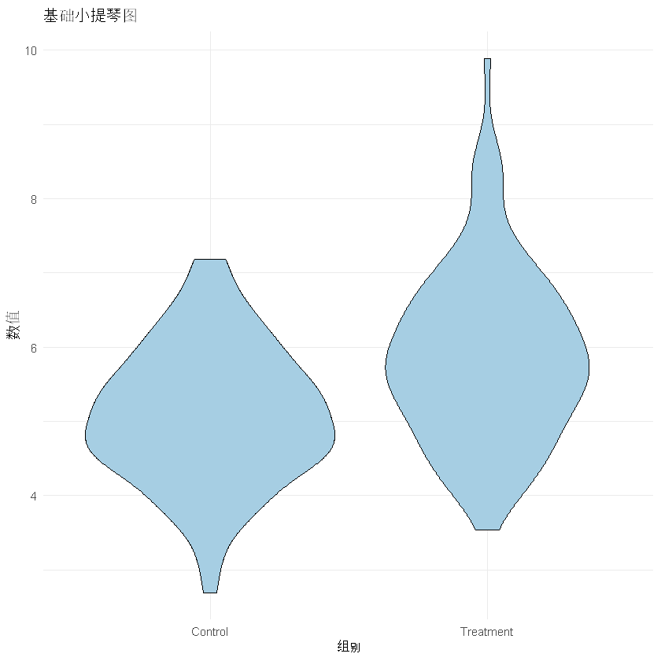

```r
ggplot(df, aes(x = group, y = value)) +
  geom_violin(fill = "#A6CEE3", colour = "black") +
  theme_minimal() +
  labs(
    title = "基础小提琴图",
    x = "组别",
    y = "数值"
  )
```

# 添加散点（展示原始数据）

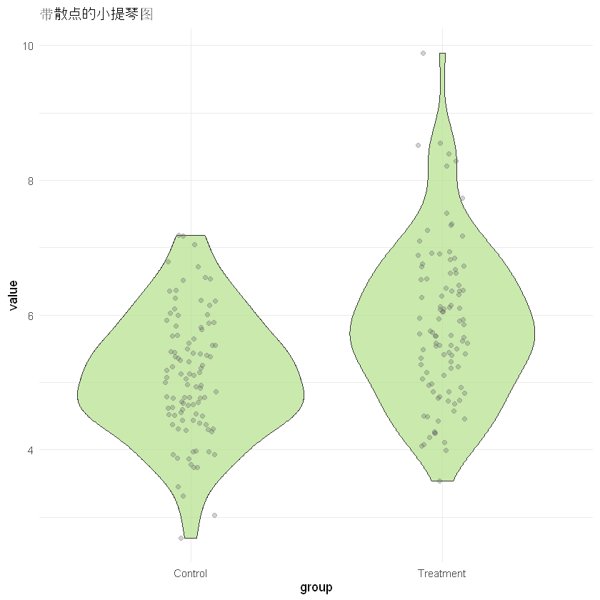

```r
ggplot(df, aes(x = group, y = value)) +
  geom_violin(fill = "#B2DF8A", alpha = 0.7) +
  geom_jitter(width = 0.1, alpha = 0.3, colour = "grey40") +
  theme_minimal() +
  labs(
    title = "带散点的小提琴图"
  )
```

# 在小提琴图中叠加箱线图

这种搭配是科研论文中的常见风格

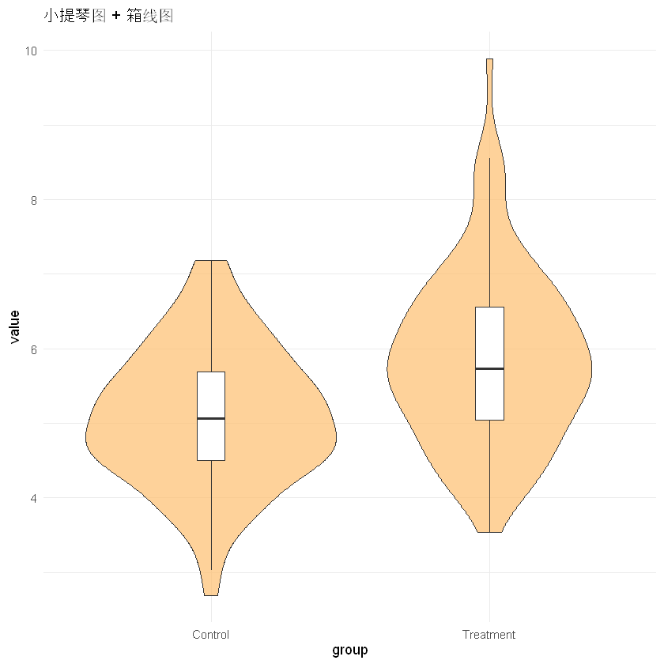

```r
ggplot(df, aes(x = group, y = value)) +
  geom_violin(fill = "#FDBF6F", alpha = 0.7) +
  geom_boxplot(width = 0.1, outlier.shape = NA, fill = "white") +
  theme_minimal() +
  labs(
    title = "小提琴图 + 箱线图"
  )
```

# 自定义颜色与主题

当然，自定义颜色和主题也很方便，ggplot2的功能非常多

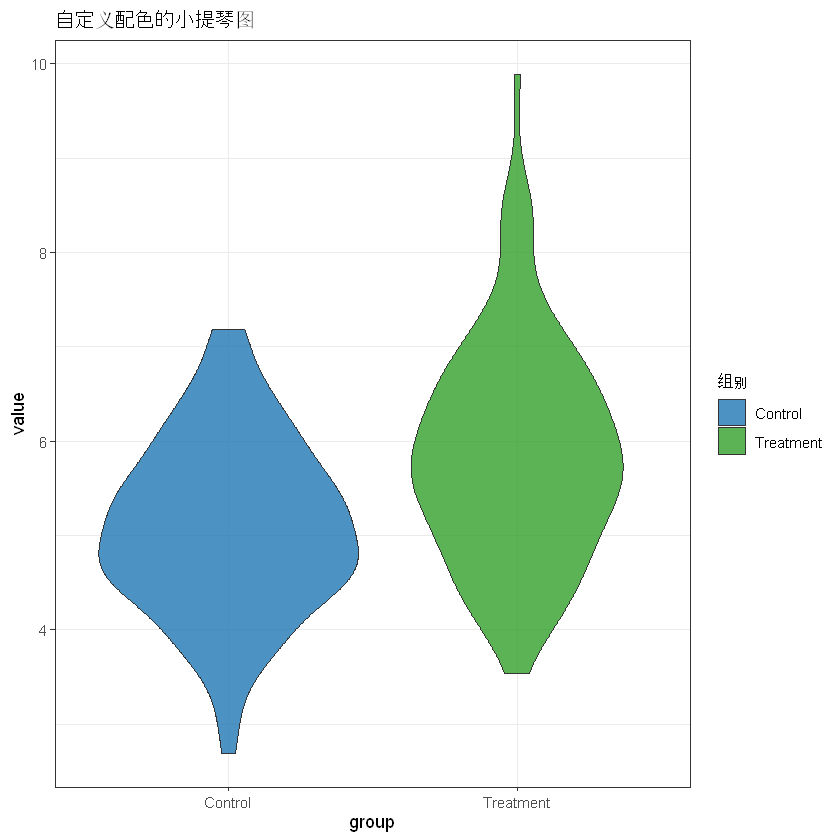

```r
ggplot(df, aes(x = group, y = value, fill = group)) +
  geom_violin(alpha = 0.8) +
  scale_fill_manual(values = c("Control" = "#1F78B4", "Treatment" = "#33A02C")) +
  theme_bw() +
  labs(
    title = "自定义配色的小提琴图",
    fill = "组别"
  )
```

# 什么时候使用小提琴图？

小提琴图适合：

- 展示完整分布形状
- 数据可能非正态
- 需要比较多个组
- 想展示多峰分布

不适合：

- 每组样本量非常小（< 10）
- 需要强调中位数/四分位数（箱线图更合适）

# 总结

本篇展示了：

- 小提琴图的数据结构
- 如何绘制基础与高级小提琴图
- 如何叠加散点与箱线图
- 如何自定义颜色与主题

小提琴图是展示数据分布的强大工具，尤其适用于生物学和实验数据分析。

Happy plotting!

*P.S. 加了一个到我Github首页的按钮……前端搞不明白啊，怎么才能显示图标呢？算了，先这么看吧*

[🐾返回主页](https://nyarlathotep438.github.io)

[🐈‍⬛GitHub Profile](https://github.com/nyarlathotep438)